# LIMPIEZA

```r
db.cmd_AS= dbscan(g.dist.cmd_AS, eps=0.06, MinPts=2,method = 'dist')
db.cmd_AS
```

```
## dbscan Pts=66 MinPts=2 eps=0.06
##        0 1  2 3
## border 2 0  0 0
## seed   0 6 53 5
## total  2 6 53 5
```

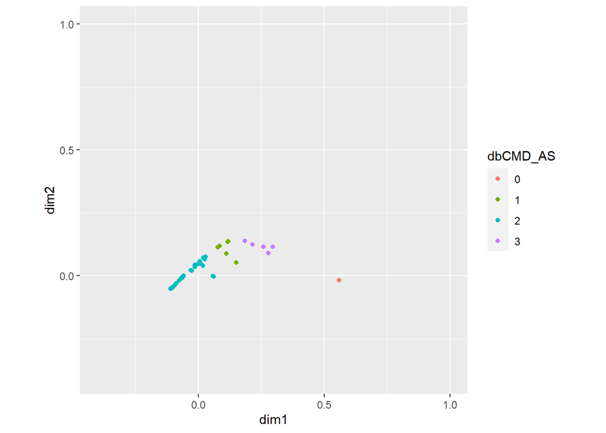

```r
Datacovidof$dbCMD_AS=as.factor(db.cmd_AS$cluster)
library(ggrepel)
base_AS= ggplot(Datacovidof,aes(x=dim1, y=dim2)) + ylim(limites) + xlim(limites) + coord_fixed()
dbplot_AS= base_AS + geom_point(aes(color=dbCMD_AS))
dbplot_AS
```

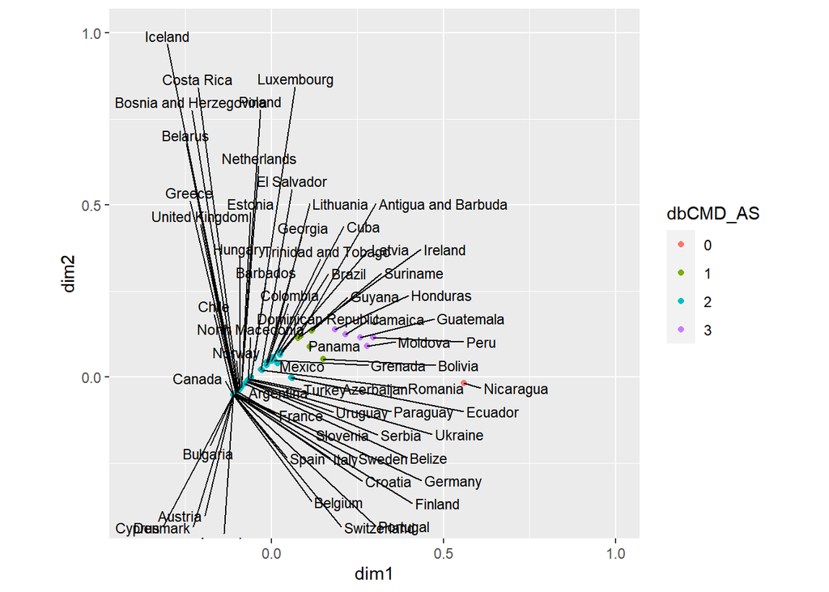

```r
dbplot_AS + geom_text_repel(size=3,aes(label=row.names(Datacovidof[,c(5,6)])))
```

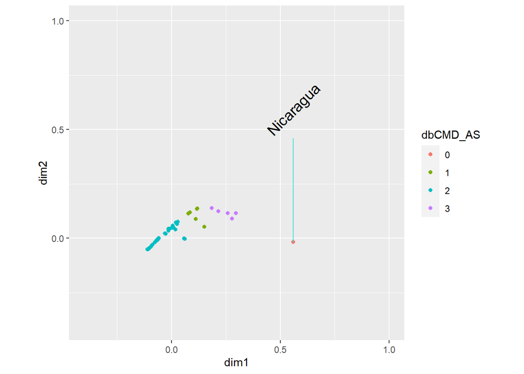

```r
LABEL=ifelse(Datacovidof$dbCMD_AS==0,row.names(Datacovidof[,c(5,6)]),"")
dbplot_AS + geom_text_repel(aes(label=LABEL),
                         size=5,
                         direction = "y", ylim = 0.45,
                         angle=45,
                         segment.colour = "turquoise")
```

```r
Dataclusters=Datacovidof[,c(1,4,18:20,23)]
names(Dataclusters)=c('Pais','Decesos','Salud_PAM','Salud_AG','Salud_DI','Gobernanza_PAM')
```

# Analisis Factorial Exploratorio (EFA)

```r
COVIDEFA=Datacovidof[,c(7:11)]
library(polycor)
MatrixCovid=polycor::hetcor(COVIDEFA)$correlations
```

#Explorar Correlaciones

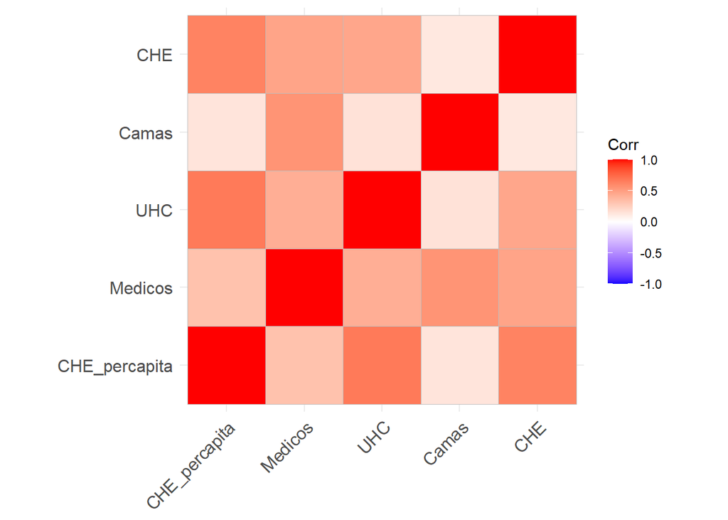

```r
library(ggcorrplot)
ggcorrplot(MatrixCovid)
```

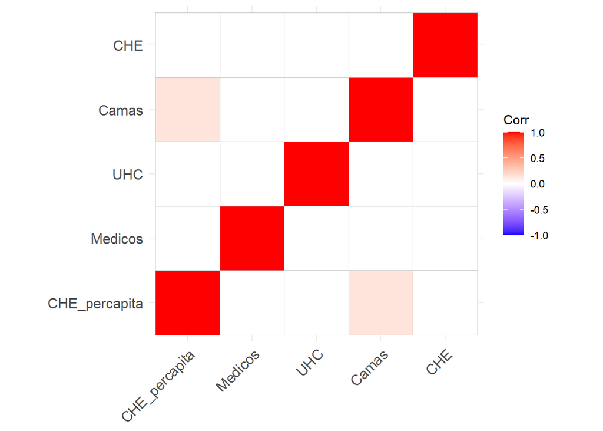

```r
ggcorrplot(MatrixCovid,
          p.mat = cor_pmat(MatrixCovid),
          insig = "blank")
```

#KMO

```r
library(psych)
psych::KMO(MatrixCovid)
```

```
## Kaiser-Meyer-Olkin factor adequacy
## Call: psych::KMO(r = MatrixCovid)
## Overall MSA =  0.6
## MSA for each item =
## CHE_percapita       Medicos           UHC         Camas           CHE
##          0.60          0.56          0.67          0.47          0.64
```

#Pruebas #HNula: para matriz identidad

```r
cortest.bartlett(MatrixCovid,n=nrow(COVIDEFA))$p.value>0.05
```

```
## [1] FALSE
```

#Hnula: para matriz singular

```r
library(matrixcalc)
is.singular.matrix(MatrixCovid)
```

```
## [1] FALSE
```

#Redimensionar

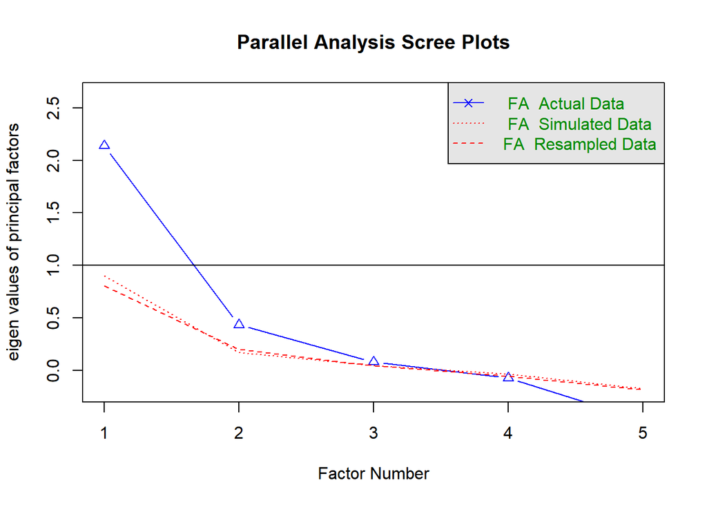

```
## Parallel analysis suggests that the number of factors =  2  and the number of components =  NA
```

```r
fa.parallel(COVIDEFA,fm = 'ML', fa = 'fa')
```

#Primer resultado

```r
library(GPArotation)
resulefa=fa(COVIDEFA,nfactors = 2,cor = 'mixed',rotate = "varimax",fm="minres")
print(resulefa$loadings)
```

```
##
## Loadings:
##               MR1   MR2
## CHE_percapita 0.979
## Medicos       0.305 0.960
## UHC           0.668 0.213
## Camas               0.534
## CHE           0.630 0.255
##
##                  MR1   MR2
## SS loadings    1.899 1.320
## Proportion Var 0.380 0.264
## Cumulative Var 0.380 0.644
```

#Resultado mejorado

```r
print(resulefa$loadings,cutoff = 0.5)
```

```
##
## Loadings:
##               MR1   MR2
## CHE_percapita 0.979
## Medicos             0.960
## UHC           0.668
## Camas               0.534
## CHE           0.630
##
##                  MR1   MR2
## SS loadings    1.899 1.320
## Proportion Var 0.380 0.264
## Cumulative Var 0.380 0.644
```

#Visualizamos

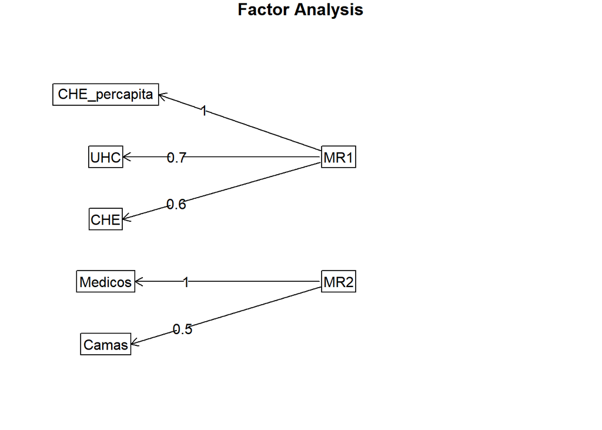

```r
fa.diagram(resulefa)
```

#Evaluación #¿La Raíz del error cuadrático medio corregida está cerca a cero?

```r
resulefa$crms
```

```
## [1] 0.09311006
```

#¿La Raíz del error cuadrático medio de aproximación es menor a 0.05?

```r
resulefa$RMSEA
```

```
##      RMSEA      lower      upper confidence
## 0.22126780 0.04064102 0.45962407 0.90000000
```

#¿El índice de Tucker-Lewis es mayor a 0.9?

```r
resulefa$TLI
```

```
## [1] 0.6881675
```

#¿Qué variables aportaron mas a los factores?

```r
sort(resulefa$communality)
```

```
##         Camas           CHE           UHC CHE_percapita       Medicos
##     0.2898239     0.4614321     0.4913899     0.9609265     1.0154577
```

#¿Qué variables contribuyen a mas de un factor?

```r
sort(resulefa$complexity)
```

```
## CHE_percapita         Camas       Medicos           UHC           CHE
##      1.004502      1.033729      1.199428      1.201218      1.319153
```

```r
COVIDEFA2=Datacovidof[,c(12:17)]
```

```r
library(polycor)
MatrixCovid2=polycor::hetcor(COVIDEFA2)$correlations
```

#Explorar Correlaciones #Sin evaluar significancia

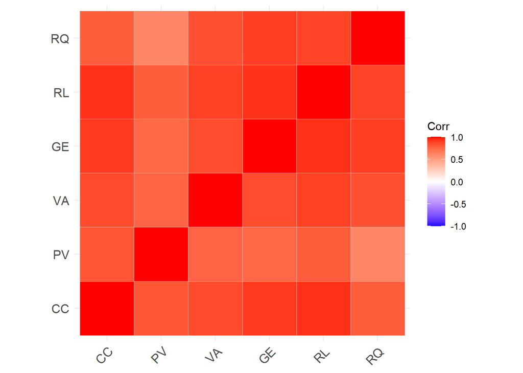

```r
library(ggcorrplot)
ggcorrplot(MatrixCovid2)
```

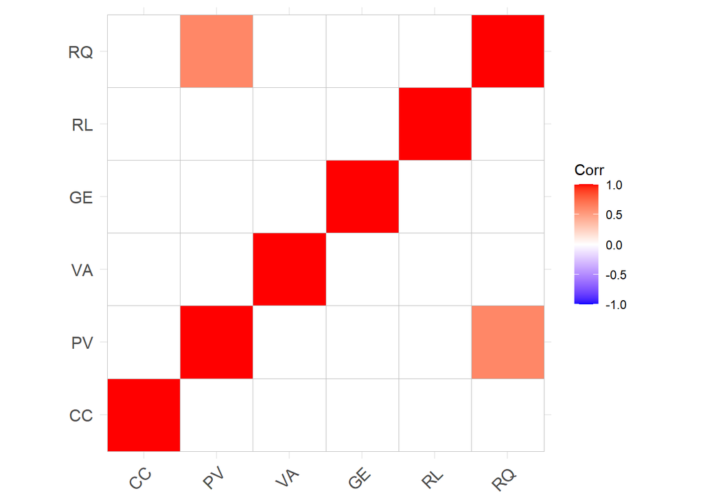

```r
ggcorrplot(MatrixCovid2,
          p.mat = cor_pmat(MatrixCovid2),
          insig = "blank")
```

```r
library(psych)
psych::KMO(MatrixCovid2)
```

```
## Kaiser-Meyer-Olkin factor adequacy
## Call: psych::KMO(r = MatrixCovid2)
## Overall MSA =  0.88
## MSA for each item =
##   CC   PV   VA   GE   RL   RQ
## 0.87 0.91 0.93 0.87 0.89 0.81
```

#Pruebas #HNula: para matriz identidad

```r
cortest.bartlett(MatrixCovid2,n=nrow(COVIDEFA2))$p.value>0.05
```

```
## [1] FALSE
```

#Hnula: para matriz singular

```r
library(matrixcalc)
is.singular.matrix(MatrixCovid2)
```

```
## [1] FALSE
```

#Redimensionar

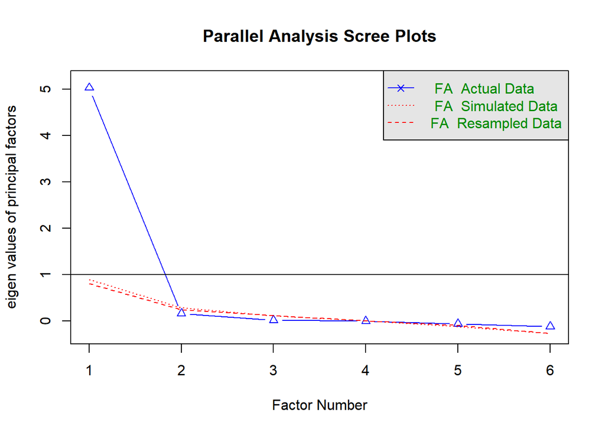

```
## Parallel analysis suggests that the number of factors =  1  and the number of components =  NA
```

```r
fa.parallel(COVIDEFA2,fm = 'ML', fa = 'fa')
```

#Primer resultado

```r
library(GPArotation)
resulefa2=fa(COVIDEFA2,nfactors = 1,cor = 'mixed',rotate = "varimax",fm="minres")
```

```r
print(resulefa2$loadings)
```

```
##
## Loadings:
##    MR1
## CC 0.951
## PV 0.797
## VA 0.917
## GE 0.957
## RL 0.982
## RQ 0.875
##
##                  MR1
## SS loadings    5.027
## Proportion Var 0.838
```

#Resultado mejorado

```r
print(resulefa2$loadings,cutoff = 0.5)
```

```
##
## Loadings:
##    MR1
## CC 0.951
## PV 0.797
## VA 0.917
## GE 0.957
## RL 0.982
## RQ 0.875
##
##                  MR1
## SS loadings    5.027
## Proportion Var 0.838
```

#Visualizamos

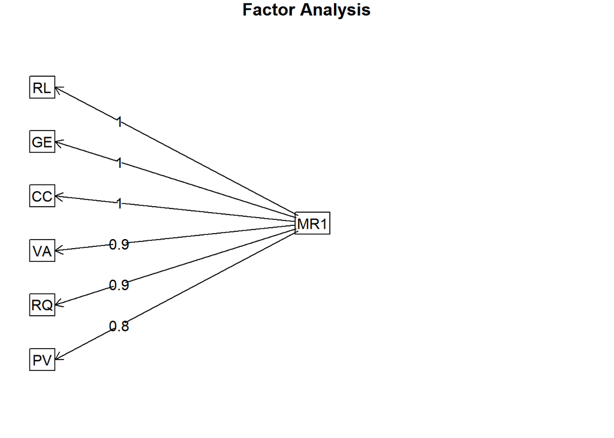

```r
fa.diagram(resulefa2)
```

```r
Modelo=' Recursos_financieros=~ CHE_percapita + CHE + UHC
          Recursos_humanos_y_materiales=~ Camas + Medicos
          Governanza=~ RL + GE + CC + VA + RQ + PV
          Agua_y_saneamiento=~ Agua + Saneamiento'
covidreg=Datacovidof[,4:17]
covidreg=scale(covidreg)
library(lavaan)
cfa=cfa(Modelo,data=covidreg,
        std.lv=TRUE,
        missing='fiml')
covidreg=as.data.frame(cbind(covidreg,lavPredict(cfa)))
```

# Regresión lineal

```r
library(stargazer)
Modelo1=formula(Decesos~Governanza)
Modelo2=formula(Decesos~Governanza+Recursos_humanos_y_materiales)
Modelo3=formula(Decesos~Governanza+Recursos_humanos_y_materiales+Recursos_financieros)
Modelo4=formula(Decesos~Governanza+Recursos_humanos_y_materiales+Recursos_financieros+Agua_y_saneamiento)
reg1cov=lm(Modelo1,data=covidreg)
stargazer(reg1cov,type='text',intercept.bottom = F)
```

```
##
## ===============================================
##                         Dependent variable:
##                     ---------------------------
##                               Decesos
## -----------------------------------------------
## Constant                       0.000
##                               (0.121)
##
## Governanza                    0.205*
##                               (0.123)
##
## -----------------------------------------------
## Observations                    66
## R2                             0.042
## Adjusted R2                    0.027
## Residual Std. Error       0.986 (df = 64)
## F Statistic             2.808* (df = 1; 64)
## ===============================================
## Note:               *p<0.1; **p<0.05; ***p<0.01
```

```r
reg2cov=lm(Modelo2,data=covidreg)
stargazer(reg2cov,type='text',intercept.bottom = F)
```

```
##
## =========================================================
##                                   Dependent variable:
##                               ---------------------------
##                                         Decesos
## ---------------------------------------------------------
## Constant                                 0.000
##                                         (0.120)
##
## Governanza                              0.322**
##                                         (0.145)
##
## Recursos_humanos_y_materiales           -0.231
##                                         (0.157)
##
## ---------------------------------------------------------
## Observations                              66
## R2                                       0.074
## Adjusted R2                              0.044
## Residual Std. Error                 0.978 (df = 63)
## F Statistic                       2.509* (df = 2; 63)
## =========================================================
## Note:                         *p<0.1; **p<0.05; ***p<0.01
```

```r
reg3cov=lm(Modelo3,data=covidreg)
stargazer(reg3cov,type='text',intercept.bottom = F)
```

```
##
## =========================================================
##                                   Dependent variable:
##                               ---------------------------
##                                         Decesos
## ---------------------------------------------------------
## Constant                                 0.000
##                                         (0.118)
##
## Governanza                              -0.128
##                                         (0.270)
##
## Recursos_humanos_y_materiales           -0.214
##                                         (0.154)
##
## Recursos_financieros                    0.512*
##                                         (0.262)
##
## ---------------------------------------------------------
## Observations                              66
## R2                                       0.128
## Adjusted R2                              0.085
## Residual Std. Error                 0.956 (df = 62)
## F Statistic                      3.020** (df = 3; 62)
## =========================================================
## Note:                         *p<0.1; **p<0.05; ***p<0.01
```

```r
reg4cov=lm(Modelo4,data=covidreg)
stargazer(reg4cov,type='text',intercept.bottom = F)
```

```
##
## =========================================================
##                                   Dependent variable:
##                               ---------------------------
##                                         Decesos
## ---------------------------------------------------------
## Constant                                 0.000
##                                         (0.118)
##
## Governanza                              -0.263
##                                         (0.303)
##
## Recursos_humanos_y_materiales           -0.273
##                                         (0.165)
##
## Recursos_financieros                    0.593**
##                                         (0.274)
##
## Agua_y_saneamiento                       0.165
##                                         (0.165)
##
## ---------------------------------------------------------
## Observations                              66
## R2                                       0.141
## Adjusted R2                              0.085
## Residual Std. Error                 0.956 (df = 61)
## F Statistic                       2.513* (df = 4; 61)
## =========================================================
## Note:                         *p<0.1; **p<0.05; ***p<0.01
```

```r
#Análisis de varianza
tanova=anova(reg1cov,reg2cov,reg3cov,reg4cov)
stargazer(tanova,type = 'text',summary = F,title = 'Tabla ANOVA')
```

```
##
## Tabla ANOVA
## ==========================================
##   Res.Df  RSS   Df Sum of Sq   F   Pr(> F)
## ------------------------------------------
## 1   64   62.268
## 2   63   60.204 1    2.064   2.256  0.138
## 3   62   56.712 1    3.492   3.818  0.055
## 4   61   55.803 1    0.908   0.993  0.323
## ------------------------------------------
```

#DIAGNOSTICO DE LA REGRESIÓN

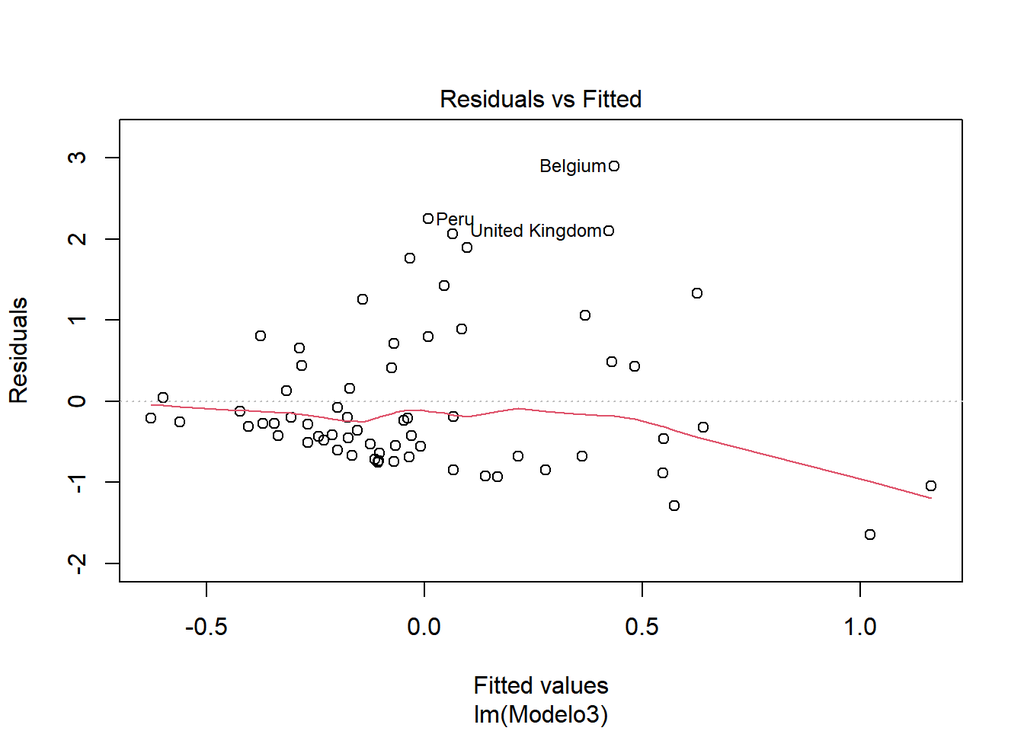

```r
#linealidad
plot(reg3cov,1)
```

```r
#Homocedasticidad
library(lmtest)
```

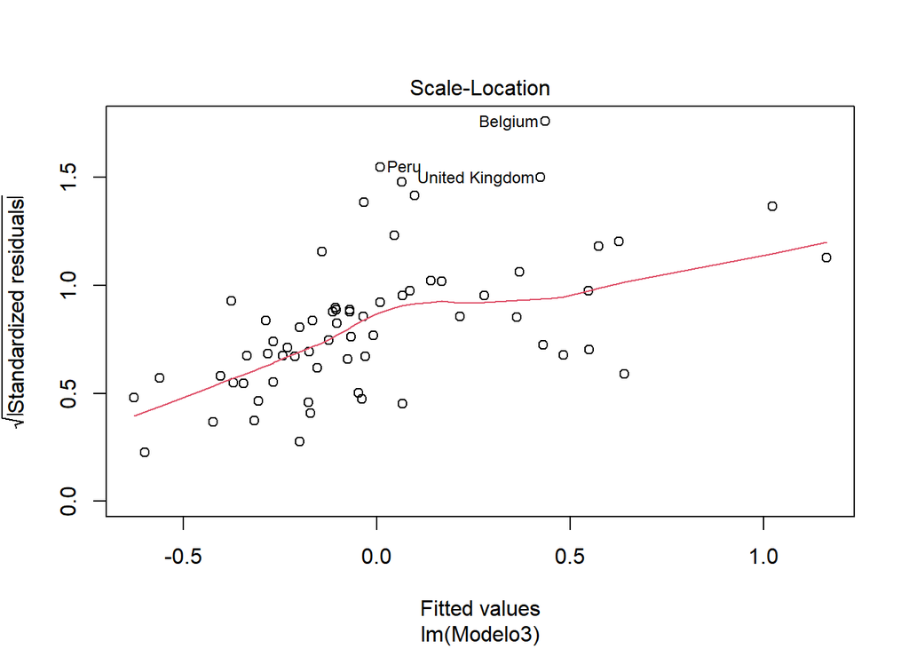

```r
plot(reg3cov,3)
```

```r
bptest(reg3cov)
```

```
##
##  studentized Breusch-Pagan test
##
## data:  reg3cov
## BP = 9.2902, df = 3, p-value = 0.02567
```

```r
#Normalidad de residuos
shapiro.test(reg3cov$residuals)
```

```
##
##  Shapiro-Wilk normality test
##
## data:  reg3cov$residuals
## W = 0.88489, p-value = 1.733e-05
```

```r
#multicolinealidad
library(DescTools)
VIF(reg3cov)
```

```
##                    Governanza Recursos_humanos_y_materiales
##                      5.173427                      1.428848
##          Recursos_financieros
##                      4.612334
```

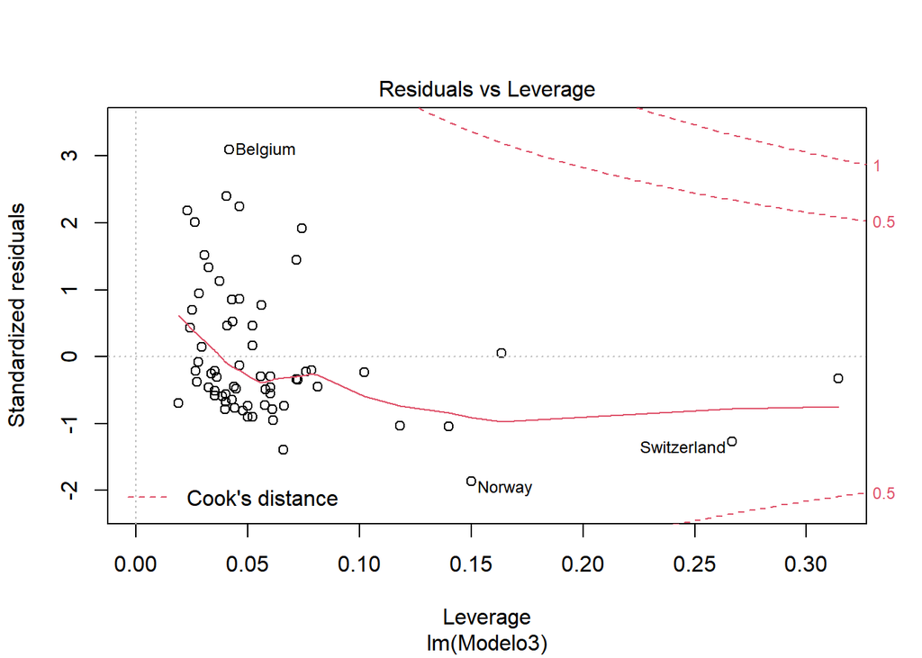

```r
#Valores influyentes
plot(reg3cov, 5)
```

```r
checkReg3=as.data.frame(influence.measures(reg3cov)$is.inf)
head(checkReg3)
```

```
##                     dfb.1_ dfb.Gvrn dfb.R___ dfb.Rcr_ dffit cov.r cook.d   hat
## Antigua and Barbuda  FALSE    FALSE    FALSE    FALSE FALSE FALSE  FALSE FALSE
## Argentina            FALSE    FALSE    FALSE    FALSE FALSE FALSE  FALSE FALSE
## Armenia              FALSE    FALSE    FALSE    FALSE FALSE FALSE  FALSE FALSE
## Austria              FALSE    FALSE    FALSE    FALSE FALSE FALSE  FALSE FALSE
## Azerbaijan           FALSE    FALSE    FALSE    FALSE FALSE FALSE  FALSE FALSE
## Barbados             FALSE    FALSE    FALSE    FALSE FALSE FALSE  FALSE FALSE
```

```r
checkReg3[checkReg3$cook.d | checkReg3$hat,]
```

```
##             dfb.1_ dfb.Gvrn dfb.R___ dfb.Rcr_ dffit cov.r cook.d  hat
## Cuba         FALSE    FALSE    FALSE    FALSE FALSE  TRUE  FALSE TRUE
## Switzerland  FALSE    FALSE    FALSE    FALSE  TRUE  TRUE  FALSE TRUE
```

```r
Modelo5=formula(Decesos~Recursos_humanos_y_materiales+Recursos_financieros)
reg5cov=lm(Modelo5,data=covidreg)
stargazer(reg5cov,type='text',intercept.bottom = F)
```

```
##
## =========================================================
##                                   Dependent variable:
##                               ---------------------------
##                                         Decesos
## ---------------------------------------------------------
## Constant                                 0.000
##                                         (0.117)
##
## Recursos_humanos_y_materiales           -0.238
##                                         (0.144)
##
## Recursos_financieros                   0.407***
##                                         (0.137)
##
## ---------------------------------------------------------
## Observations                              66
## R2                                       0.124
## Adjusted R2                              0.097
## Residual Std. Error                 0.950 (df = 63)
## F Statistic                      4.474** (df = 2; 63)
## =========================================================
## Note:                         *p<0.1; **p<0.05; ***p<0.01
```

```r
tanova_covid=anova(reg3cov,reg5cov)
stargazer(tanova_covid,type = 'text',summary = F,title = 'Tabla ANOVA')
```

```
##
## Tabla ANOVA
## ==========================================
##   Res.Df  RSS   Df Sum of Sq   F   Pr(> F)
## ------------------------------------------
## 1   62   56.712
## 2   63   56.916 -1  -0.205   0.224  0.638
## ------------------------------------------
```

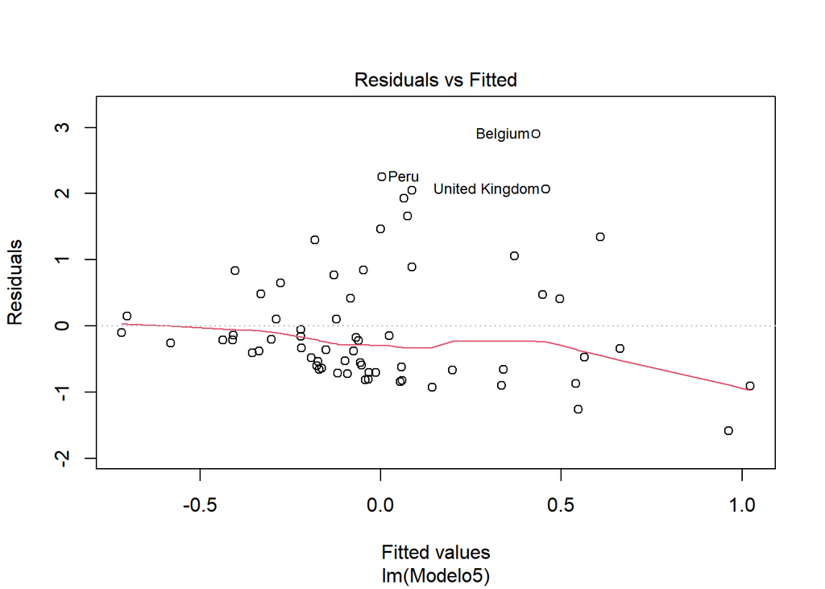

```r
plot(reg5cov,1)
```

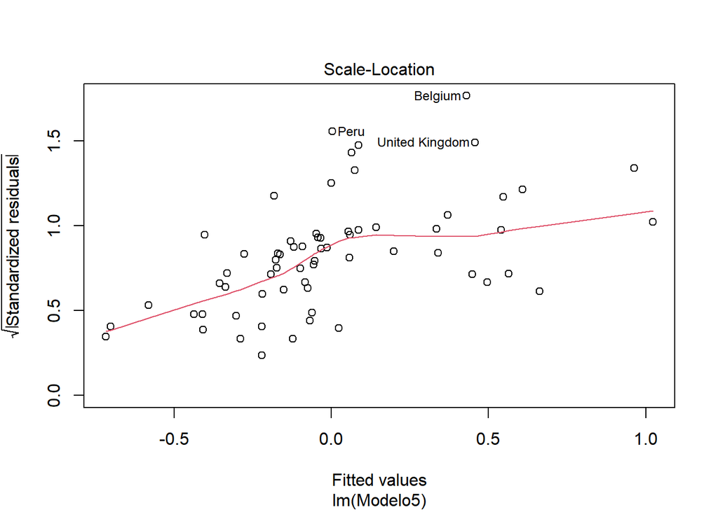

```r
library(lmtest)
plot(reg5cov,3)
```

```r
bptest(reg5cov)
```

```
##
##  studentized Breusch-Pagan test
##
## data:  reg5cov
## BP = 8.5141, df = 2, p-value = 0.01416
```

```r
shapiro.test(reg5cov$residuals)
```

```
##
##  Shapiro-Wilk normality test
##
## data:  reg5cov$residuals
## W = 0.88304, p-value = 1.49e-05
```

```r
library(DescTools)
VIF(reg5cov)
```

```
## Recursos_humanos_y_materiales          Recursos_financieros
##                      1.269903                      1.269903
```

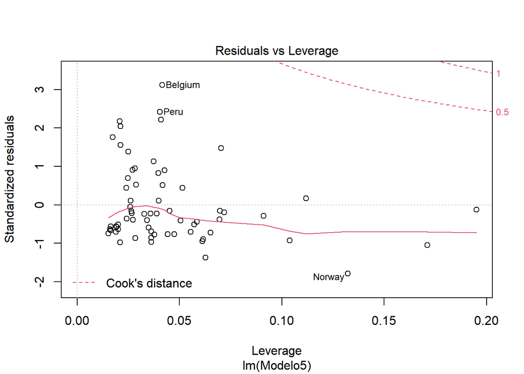

```r
plot(reg5cov,5)
```

```r
checkReg5=as.data.frame(influence.measures(reg5cov)$is.inf)
head(checkReg5)
```

```
##                     dfb.1_ dfb.R___ dfb.Rcr_ dffit cov.r cook.d   hat
## Antigua and Barbuda  FALSE    FALSE    FALSE FALSE FALSE  FALSE FALSE
## Argentina            FALSE    FALSE    FALSE FALSE FALSE  FALSE FALSE
## Armenia              FALSE    FALSE    FALSE FALSE FALSE  FALSE FALSE
## Austria              FALSE    FALSE    FALSE FALSE FALSE  FALSE FALSE
## Azerbaijan           FALSE    FALSE    FALSE FALSE FALSE  FALSE FALSE
## Barbados             FALSE    FALSE    FALSE FALSE FALSE  FALSE FALSE
```

```r
checkReg5[checkReg5$cook.d | checkReg5$hat,]
```

```
##             dfb.1_ dfb.R___ dfb.Rcr_ dffit cov.r cook.d  hat
## Cuba         FALSE    FALSE    FALSE FALSE  TRUE  FALSE TRUE
## Switzerland  FALSE    FALSE    FALSE FALSE  TRUE  FALSE TRUE
```

```r
covidreg=covidreg[-c(19,61),]
```

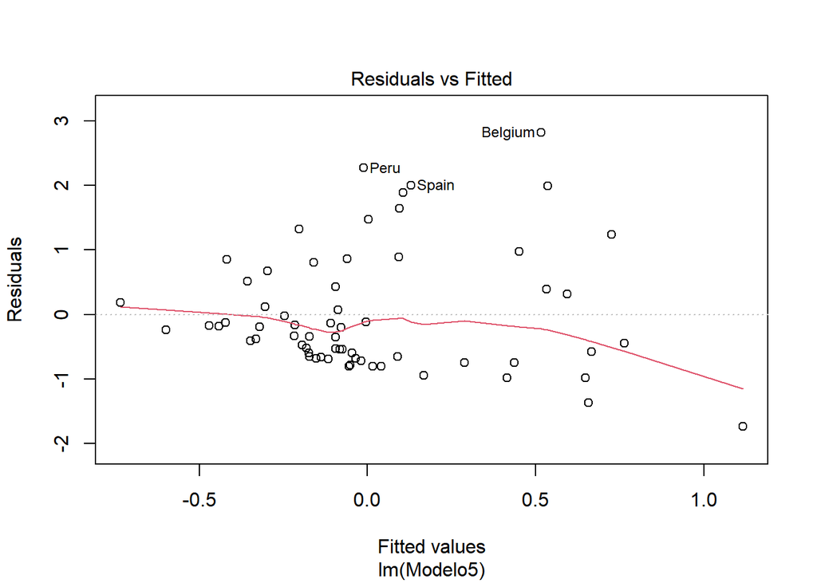

```r
reg5cov=lm(Modelo5,data=covidreg)
plot(reg5cov,1)
```

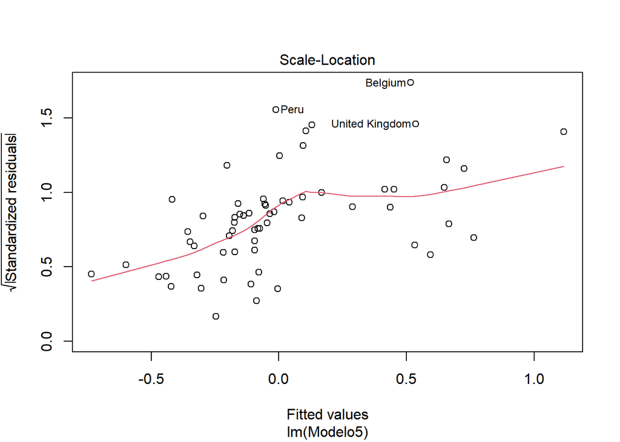

```r
plot(reg5cov,3)
```

```r
bptest(reg5cov)
```

```
##
##  studentized Breusch-Pagan test
##
## data:  reg5cov
## BP = 10.516, df = 2, p-value = 0.005205
```

```r
shapiro.test(reg5cov$residuals)
```

```
##
##  Shapiro-Wilk normality test
##
## data:  reg5cov$residuals
## W = 0.89917, p-value = 7.444e-05
```

```r
VIF(reg5cov)
```

```
## Recursos_humanos_y_materiales          Recursos_financieros
##                      1.322148                      1.322148
```

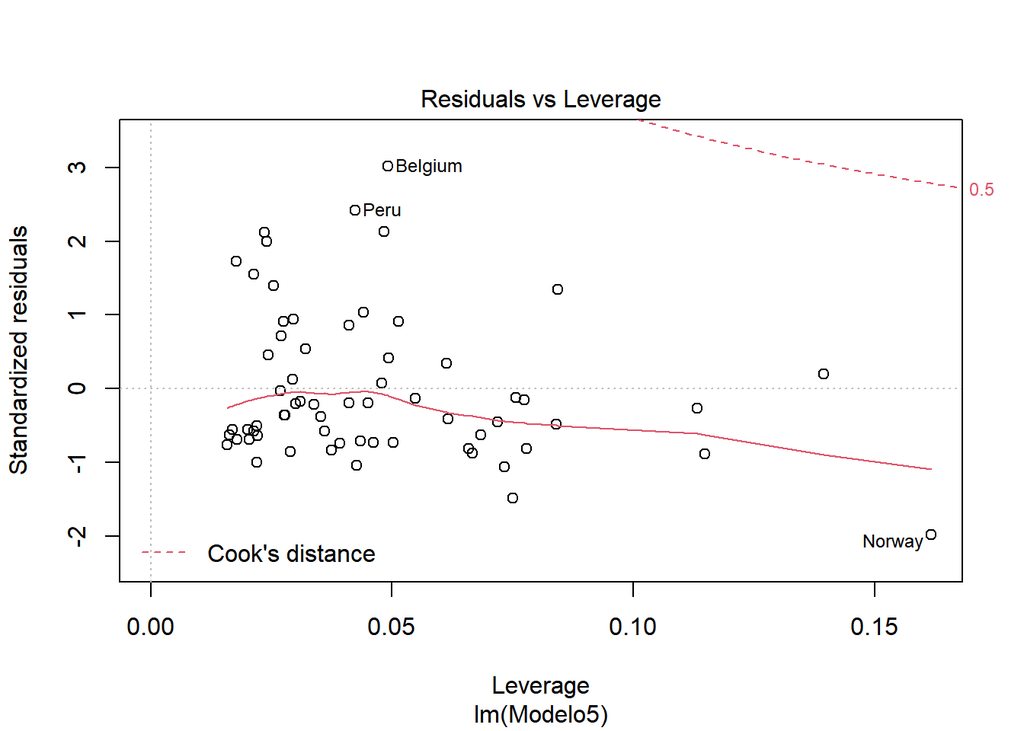

```r
plot(reg5cov, 5)
```

```r
checkReg5=as.data.frame(influence.measures(reg5cov)$is.inf)
head(checkReg5)
```

```
##                     dfb.1_ dfb.R___ dfb.Rcr_ dffit cov.r cook.d   hat
## Antigua and Barbuda  FALSE    FALSE    FALSE FALSE FALSE  FALSE FALSE
## Argentina            FALSE    FALSE    FALSE FALSE FALSE  FALSE FALSE
## Armenia              FALSE    FALSE    FALSE FALSE FALSE  FALSE FALSE
## Austria              FALSE    FALSE    FALSE FALSE FALSE  FALSE FALSE
## Azerbaijan           FALSE    FALSE    FALSE FALSE FALSE  FALSE FALSE
## Barbados             FALSE    FALSE    FALSE FALSE FALSE  FALSE FALSE
```

```r
checkReg5[checkReg5$cook.d | checkReg5$hat,]
```

```
##        dfb.1_ dfb.R___ dfb.Rcr_ dffit cov.r cook.d  hat
## Norway  FALSE    FALSE    FALSE  TRUE FALSE  FALSE TRUE
```

```r
covidreg=covidreg[-c(48),]
```

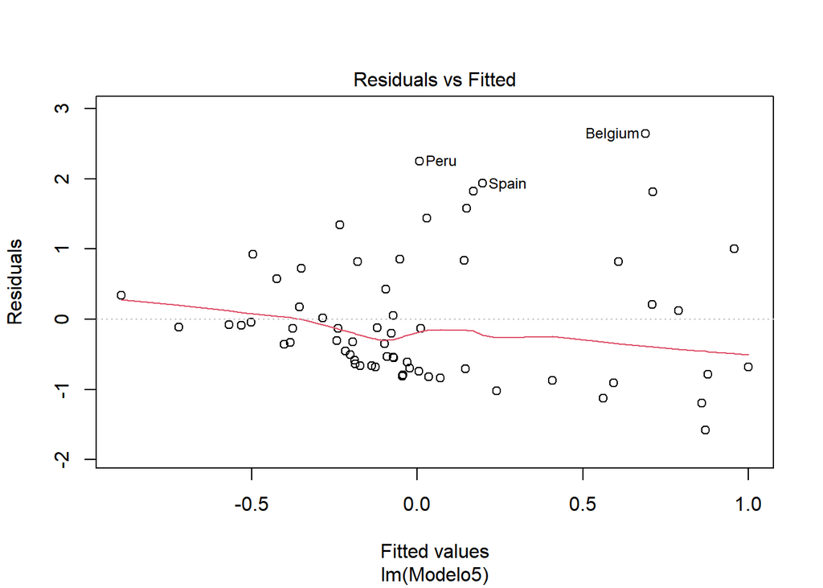

```r
reg5cov=lm(Modelo5,data=covidreg)
plot(reg5cov,1)
```

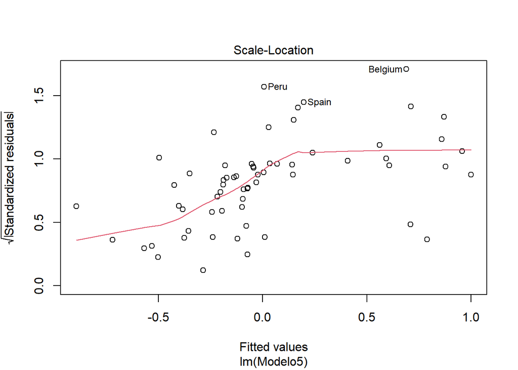

```r
plot(reg5cov,3)
```

```r
bptest(reg5cov)
```

```
##
##  studentized Breusch-Pagan test
##
## data:  reg5cov
## BP = 9.6338, df = 2, p-value = 0.008092
```

```r
shapiro.test(reg5cov$residuals)
```

```
##
##  Shapiro-Wilk normality test
##
## data:  reg5cov$residuals
## W = 0.91116, p-value = 0.000243
```

```r
VIF(reg5cov)
```

```
## Recursos_humanos_y_materiales          Recursos_financieros
##                      1.366817                      1.366817
```

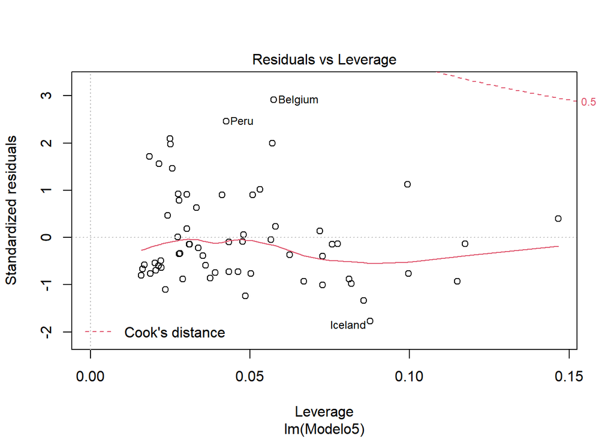

```r
plot(reg5cov, 5)
```

```r
checkReg5=as.data.frame(influence.measures(reg5cov)$is.inf)
head(checkReg5)
```

```
##                     dfb.1_ dfb.R___ dfb.Rcr_ dffit cov.r cook.d   hat
## Antigua and Barbuda  FALSE    FALSE    FALSE FALSE FALSE  FALSE FALSE
## Argentina            FALSE    FALSE    FALSE FALSE FALSE  FALSE FALSE
## Armenia              FALSE    FALSE    FALSE FALSE FALSE  FALSE FALSE
## Austria              FALSE    FALSE    FALSE FALSE FALSE  FALSE FALSE
## Azerbaijan           FALSE    FALSE    FALSE FALSE FALSE  FALSE FALSE
## Barbados             FALSE    FALSE    FALSE FALSE FALSE  FALSE FALSE
```

```r
checkReg5[checkReg5$cook.d | checkReg5$hat,]
```

```
##         dfb.1_ dfb.R___ dfb.Rcr_ dffit cov.r cook.d  hat
## Belarus  FALSE    FALSE    FALSE FALSE  TRUE  FALSE TRUE
```

```r
covidreg=covidreg[-c(7),]
```

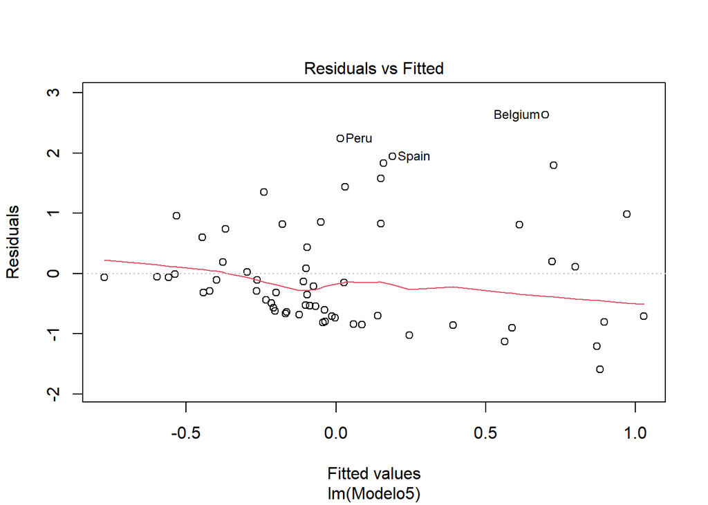

```r
reg5cov=lm(Modelo5,data=covidreg)
plot(reg5cov,1)
```

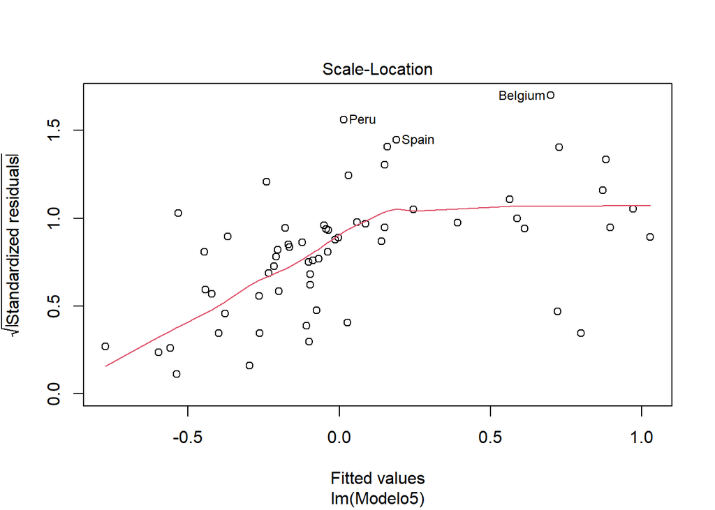

```r
plot(reg5cov,3)
```

```r
bptest(reg5cov)
```

```
##
##  studentized Breusch-Pagan test
##
## data:  reg5cov
## BP = 9.368, df = 2, p-value = 0.009242
```

```r
shapiro.test(reg5cov$residuals)
```

```
##
##  Shapiro-Wilk normality test
##
## data:  reg5cov$residuals
## W = 0.91119, p-value = 0.0002736
```

```r
VIF(reg5cov)
```

```
## Recursos_humanos_y_materiales          Recursos_financieros
##                      1.466131                      1.466131
```

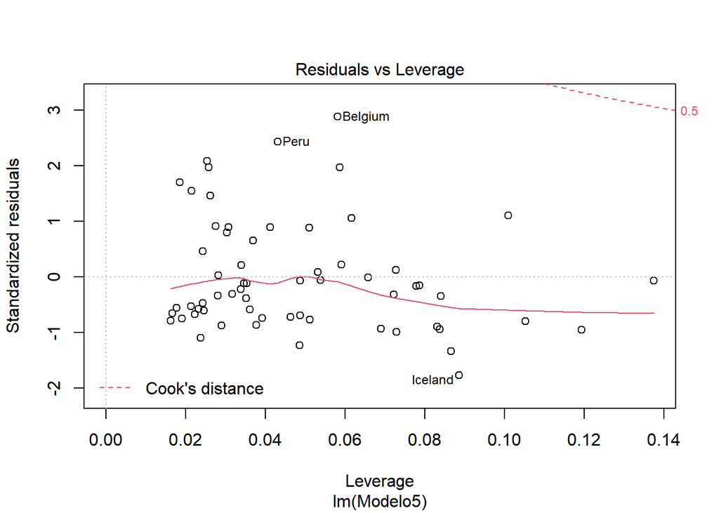

```r
plot(reg5cov, 5)
```

```r
checkReg5=as.data.frame(influence.measures(reg5cov)$is.inf)
head(checkReg5)
```

```
##                     dfb.1_ dfb.R___ dfb.Rcr_ dffit cov.r cook.d   hat
## Antigua and Barbuda  FALSE    FALSE    FALSE FALSE FALSE  FALSE FALSE
## Argentina            FALSE    FALSE    FALSE FALSE FALSE  FALSE FALSE
## Armenia              FALSE    FALSE    FALSE FALSE FALSE  FALSE FALSE
## Austria              FALSE    FALSE    FALSE FALSE FALSE  FALSE FALSE
## Azerbaijan           FALSE    FALSE    FALSE FALSE FALSE  FALSE FALSE
## Barbados             FALSE    FALSE    FALSE FALSE FALSE  FALSE FALSE
```

```r
checkReg5[checkReg5$cook.d | checkReg5$hat,]
```

```
## [1] dfb.1_   dfb.R___ dfb.Rcr_ dffit    cov.r    cook.d   hat
## <0 rows> (or 0-length row.names)
```

# Recursos financieros

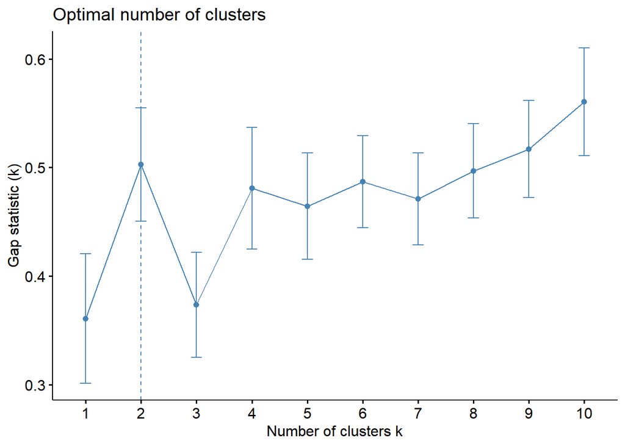

```r
Datacovidof2=merge(dataCovid,merge2,all.x = T,all.y = T)
names(Datacovidof2)=c("Pais","Region","Subregion","Decesos","Agua","Saneamiento","CHE_percapita","Medicos","UHC","Camas","CHE","CC","PV","VA","GE","RL","RQ")
Datacovidof2[,c(2:3,5:6,12:17)]=NULL
Datacovidof2[,c(4,6)]=NULL
row.names(Datacovidof2)=Datacovidof2$Pais
Datacovidof2=na.omit(Datacovidof2)
g.dist_rec = daisy(Datacovidof2[,c(2:5)], metric='gower')
fviz_nbclust(Datacovidof2[,c(2:5)], pam,diss=g.dist_rec,method = 'gap_stat',k.max = 10,verbose = F)
```

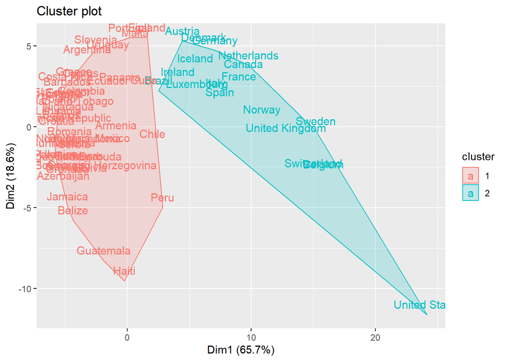

```r
res.pam_rec=pam(g.dist_rec,2,cluster.only = F)
Datacovidof2$clusterPT_rec=res.pam_rec$cluster
fviz_cluster(object = list(data=g.dist_rec, cluster = Datacovidof2$clusterPT_rec),
             geom = c("text"),
             ellipse.type = "convex")
```

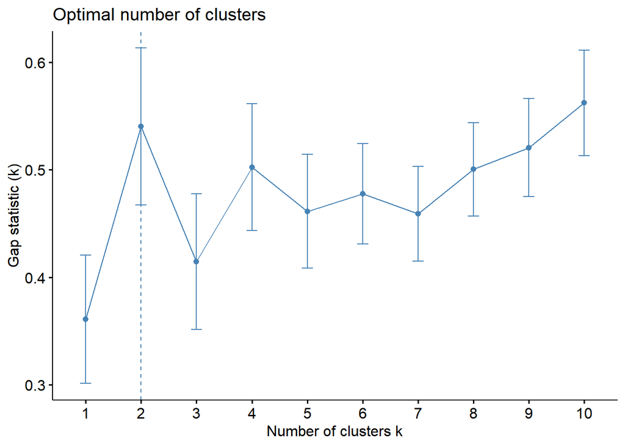

```r
fviz_nbclust(Datacovidof2[,c(2:5)], hcut,diss=g.dist_rec,method = 'gap_stat',k.max = 10,verbose = F)
```

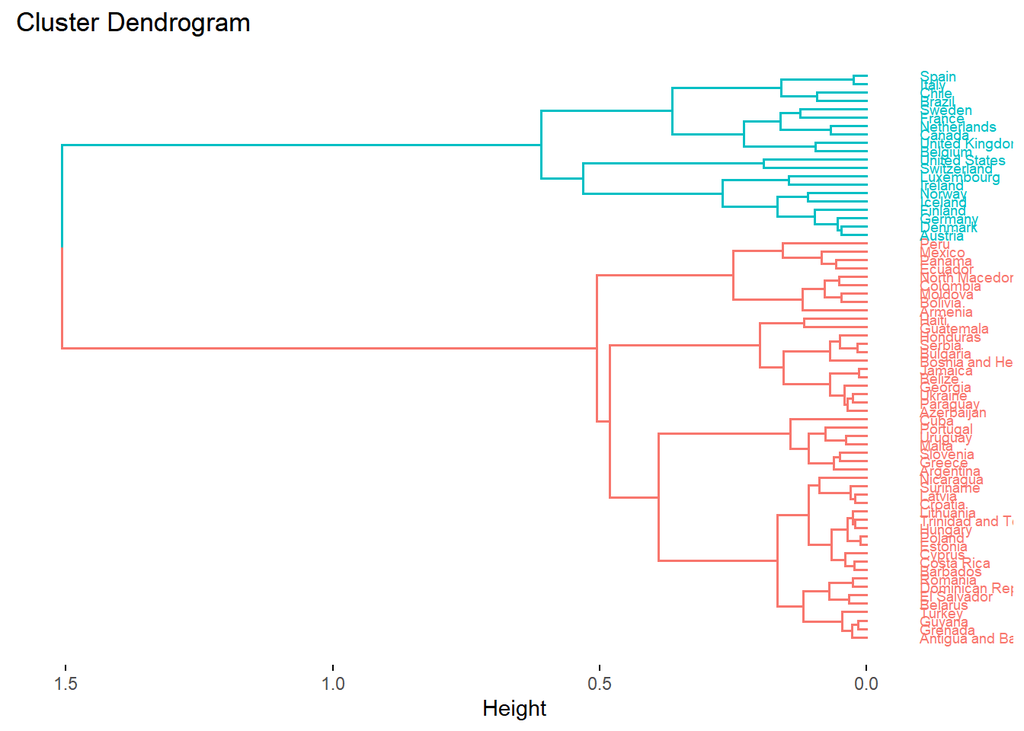

```r
res.agnes_rec = hcut(g.dist_rec, k = 2,hc_func='agnes',hc_method = 'ward.D')
Datacovidof2$clustAG_rec=res.agnes_rec$cluster
fviz_dend(res.agnes_rec,k=2, cex = 0.5, horiz = T)
```

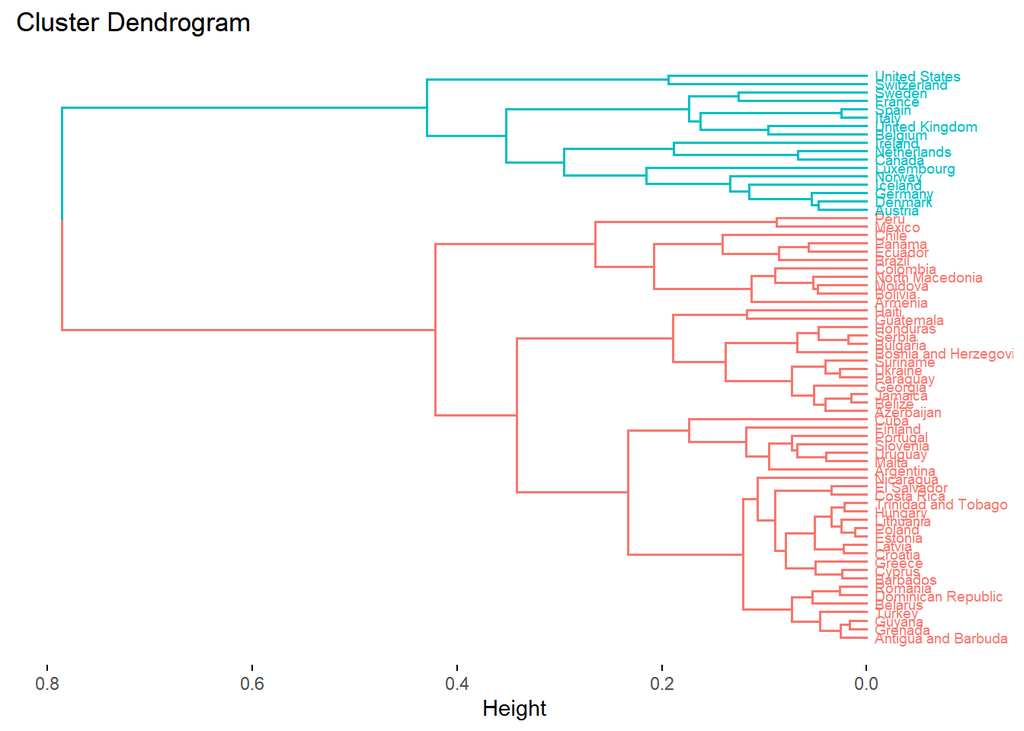

```r
res.diana_rec = hcut(g.dist_rec, k = 2,hc_func='diana')
Datacovidof2$clustDIV_rec=res.diana_rec$cluster
fviz_dend(res.diana_rec, cex = 0.5,horiz = T)
```

```
##   cluster size ave.sil.width
## 1       1   50          0.57
## 2       2   18          0.31
```

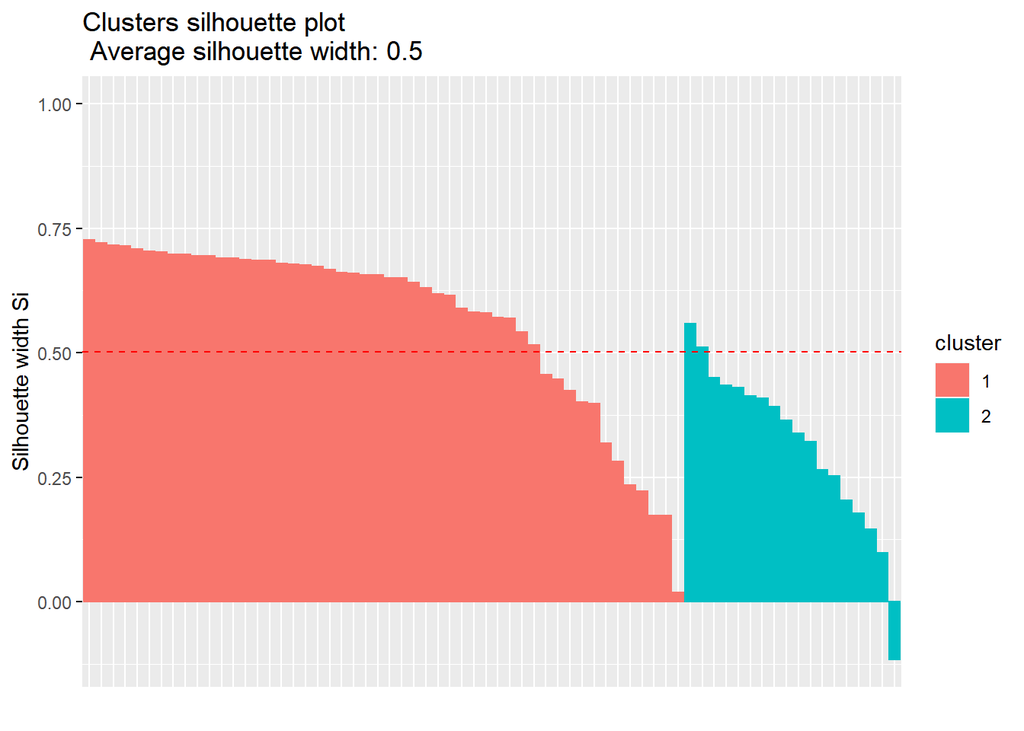

```r
fviz_silhouette(res.pam_rec)
```

```
##   cluster size ave.sil.width
## 1       1   48          0.58
## 2       2   20          0.27
```

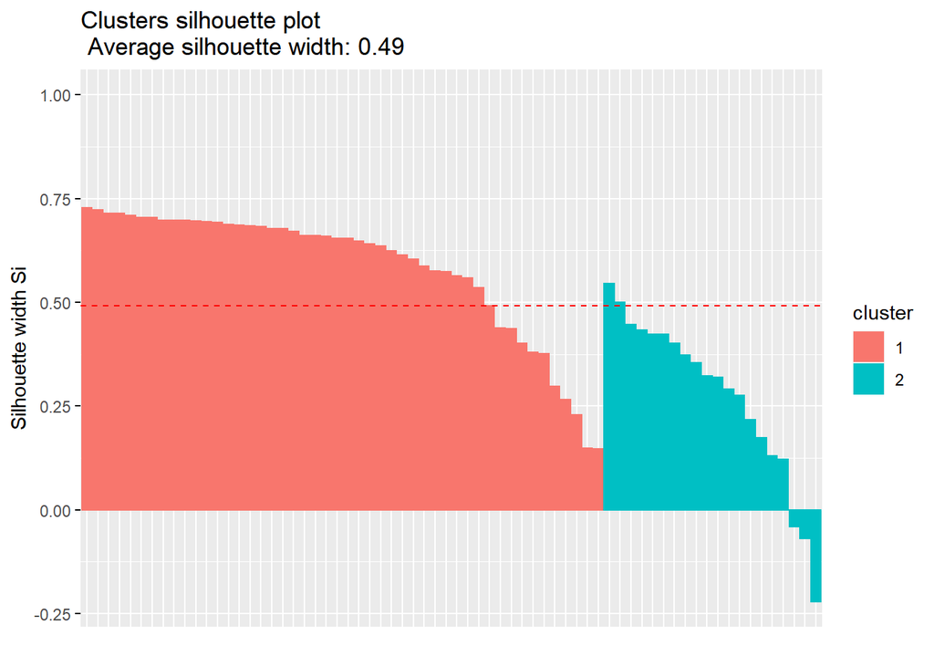

```r
fviz_silhouette(res.agnes_rec)
```

```
##   cluster size ave.sil.width
## 1       1   51          0.57
## 2       2   17          0.34
```

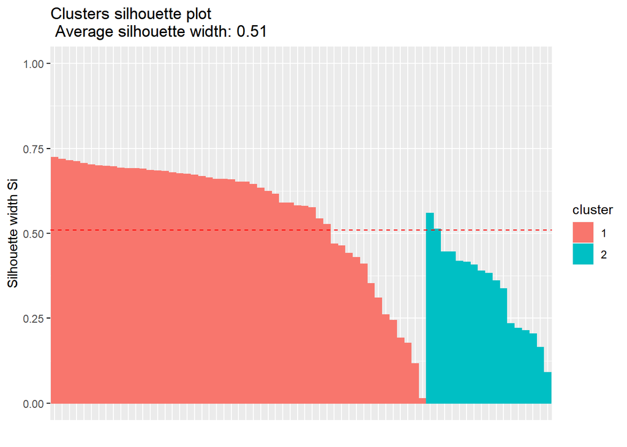

```r
fviz_silhouette(res.diana_rec)
```

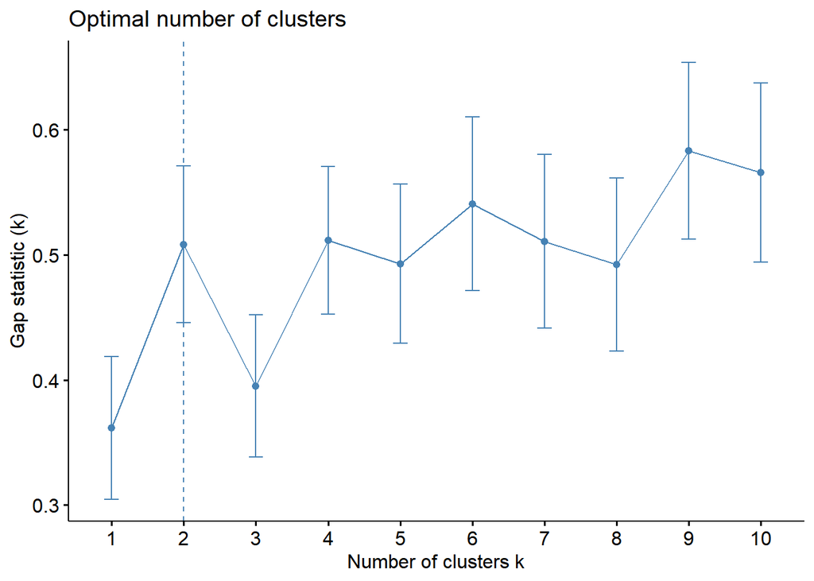

```r
g.dist_rec2 = daisy(Datacovidof2[,c(3:5)], metric='gower')
fviz_nbclust(Datacovidof2[,c(3:5)], pam,diss=g.dist_rec,method = 'gap_stat',k.max = 10,verbose = F)
```

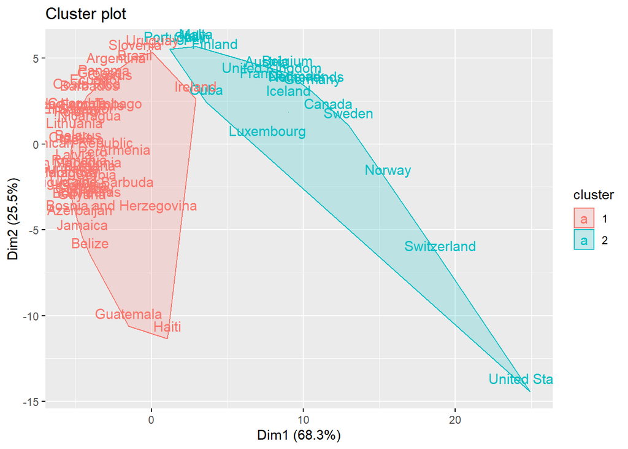

```r
res.pam_rec2=pam(g.dist_rec2,2,cluster.only = F)
Datacovidof2$clusterPT_rec2=res.pam_rec2$cluster
fviz_cluster(object = list(data=g.dist_rec2, cluster = Datacovidof2$clusterPT_rec2),
             geom = c("text"),
             ellipse.type = "convex")
```

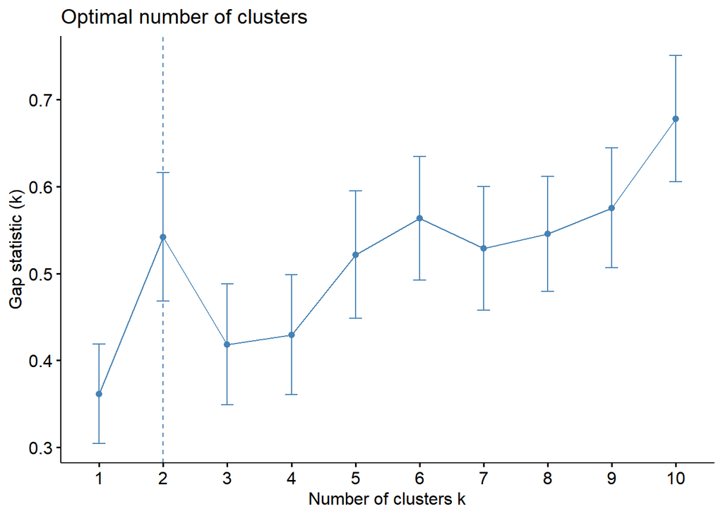

```r
fviz_nbclust(Datacovidof2[,c(3:5)], hcut,diss=g.dist_rec2,method = 'gap_stat',k.max = 10,verbose = F)
```

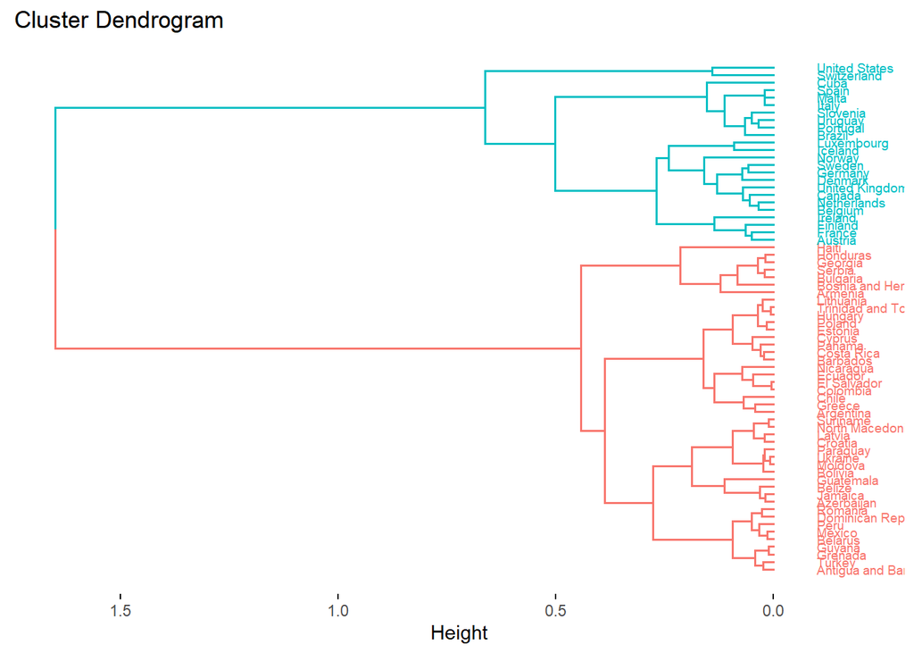

```r
res.agnes_rec2 = hcut(g.dist_rec2, k = 2,hc_func='agnes',hc_method = 'ward.D')
Datacovidof2$clustAG_rec2=res.agnes_rec2$cluster
fviz_dend(res.agnes_rec2,k=2, cex = 0.5, horiz = T)
```

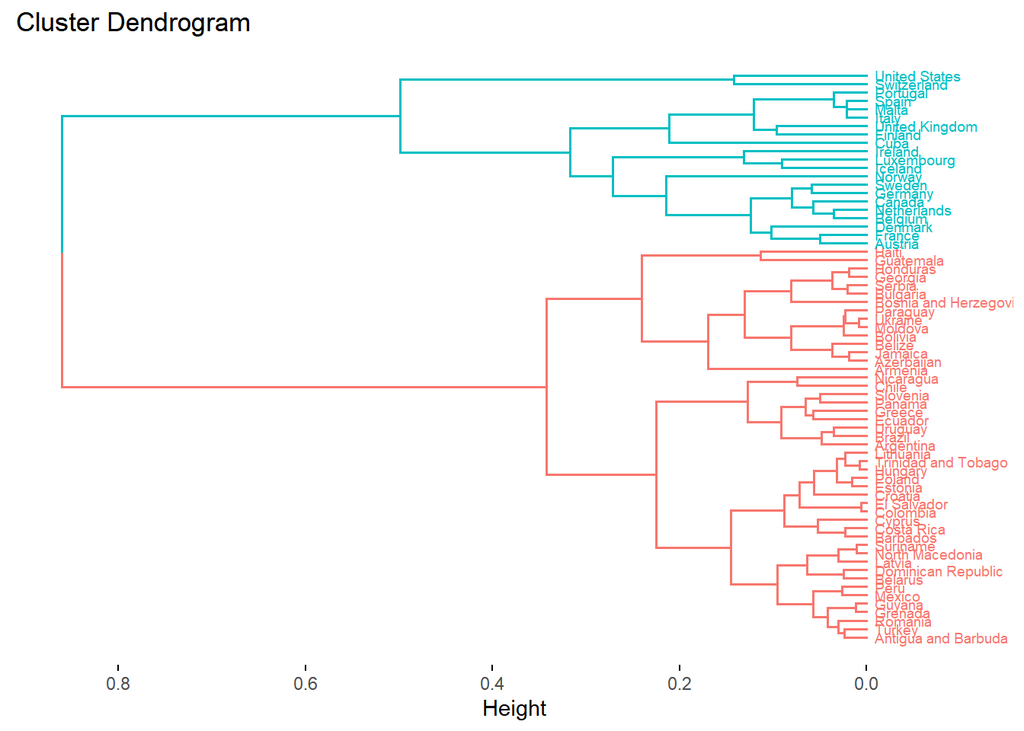

```r
res.diana_rec2 = hcut(g.dist_rec2, k = 2,hc_func='diana')
Datacovidof2$clustDIV_rec2=res.diana_rec2$cluster
fviz_dend(res.diana_rec2, cex = 0.5,horiz = T)
```

```
##   cluster size ave.sil.width
## 1       1   48          0.62
## 2       2   20          0.44
```

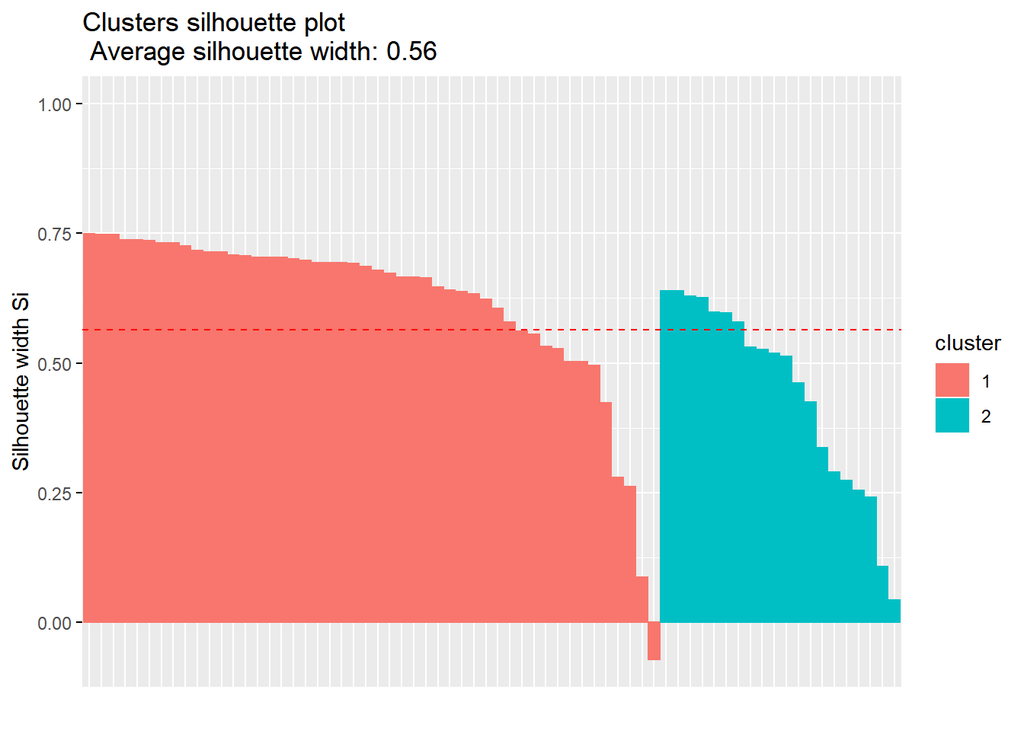

```r
fviz_silhouette(res.pam_rec2)
```

```
##   cluster size ave.sil.width
## 1       1   44          0.64
## 2       2   24          0.37
```

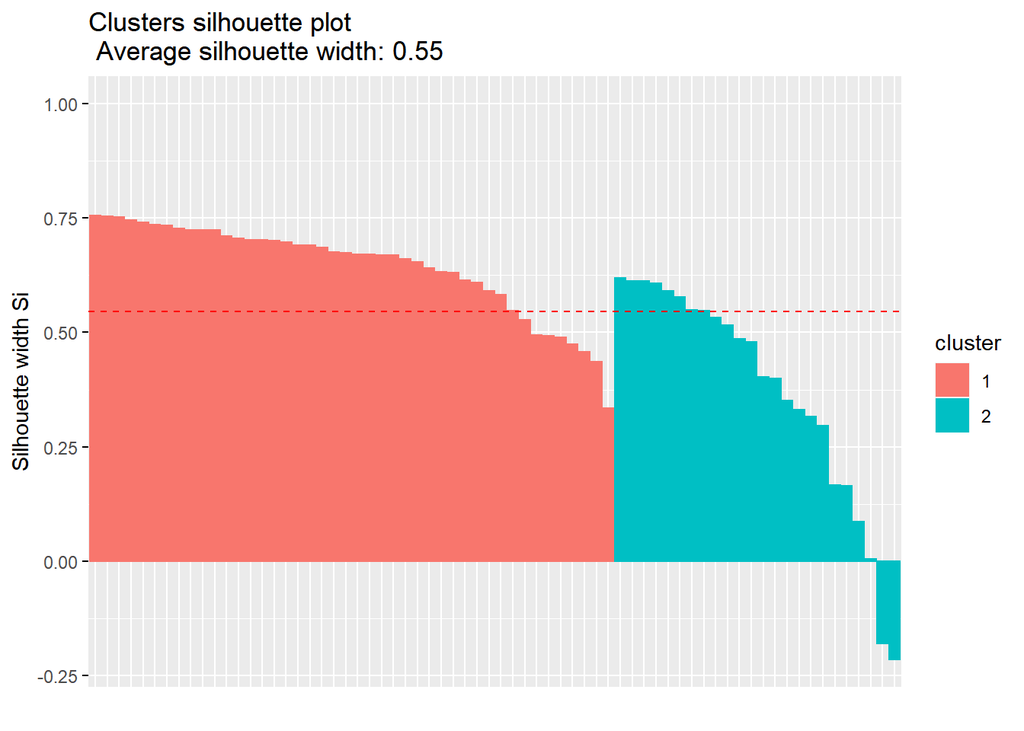

```r
fviz_silhouette(res.agnes_rec2)
```

```
##   cluster size ave.sil.width
## 1       1   47          0.63
## 2       2   21          0.42
```

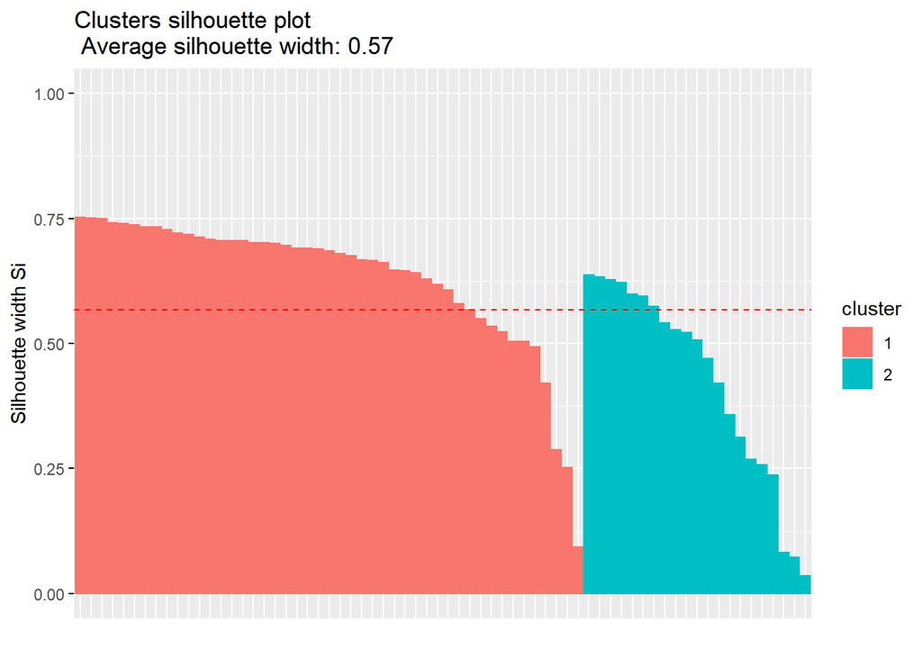

```r
fviz_silhouette(res.diana_rec2)
```

```r
cluster2_rec=Datacovidof2[Datacovidof2$clustDIV_rec==2,'Pais']
cluster2_rec2=Datacovidof2[Datacovidof2$clustDIV_rec2==2,'Pais']
intersect(cluster2_rec,cluster2_rec2)
```

```
##  [1] "Austria"        "Belgium"        "Canada"         "Denmark"
##  [5] "France"         "Germany"        "Iceland"        "Ireland"
##  [9] "Italy"          "Luxembourg"     "Netherlands"    "Norway"
## [13] "Spain"          "Sweden"         "Switzerland"    "United Kingdom"
## [17] "United States"
```

```r
setdiff(cluster2_rec2,cluster2_rec)
```

```
## [1] "Cuba"     "Finland"  "Malta"    "Portugal"
```

```r
Modelo6A=formula(Decesos~ UHC+CHE+CHE_percapita)
reg6Acov=lm(Modelo6A,data=Datacovidof2)
stargazer(reg6Acov,type='text',intercept.bottom = F)
```

```
##
## ===============================================
##                         Dependent variable:
##                     ---------------------------
##                               Decesos
## -----------------------------------------------
## Constant                    -649.167**
##                              (302.896)
##
## UHC                           8.739**
##                               (4.046)
##
## CHE                           23.196
##                              (14.642)
##
## CHE_percapita                 -0.007
##                               (0.016)
##
## -----------------------------------------------
## Observations                    68
## R2                             0.191
## Adjusted R2                    0.153
## Residual Std. Error      189.144 (df = 64)
## F Statistic            5.046*** (df = 3; 64)
## ===============================================
## Note:               *p<0.1; **p<0.05; ***p<0.01
```

```r
Datacovidof2=Datacovidof2[-c(4,8,14,21,27,29,37:39,43,47,50,59,61:62,66:67),]
```

```r
Modelo6B=formula(Decesos~ UHC+CHE+CHE_percapita)
reg6Bcov=lm(Modelo6B,data=Datacovidof2)
stargazer(reg6Bcov,type='text',intercept.bottom = F)
```

```
##
## ===============================================
##                         Dependent variable:
##                     ---------------------------
##                               Decesos
## -----------------------------------------------
## Constant                     -396.802
##                              (278.892)
##
## UHC                           6.580*
##                               (3.754)
##
## CHE                           12.753
##                              (14.434)
##
## CHE_percapita                 -0.064*
##                               (0.036)
##
## -----------------------------------------------
## Observations                    51
## R2                             0.083
## Adjusted R2                    0.025
## Residual Std. Error      147.296 (df = 47)
## F Statistic             1.422 (df = 3; 47)
## ===============================================
## Note:               *p<0.1; **p<0.05; ***p<0.01
```